# R Notebook

Set up the libraries;

```r
library(tidyverse)
library(scales)
```

```r
backpack <- CodeClanData::backpack %>% janitor::clean_names()
```

# Question 1.

Load in the libraries you need, and look at the backpack data. Take note of variable names and dimensions.

Backpack contains 100 observations of 9 variables, detailing various students, their gender , subject of study , body weight , their backpack weights , an indication of back pain and some details such as “units” and “status” by year .

# Question 2.

What is the distribution of backpack weights that students are carrying? Choose an appropriate graph to show the distribution.

A histogram would be a reasonable plot to show backpackweight distribution;

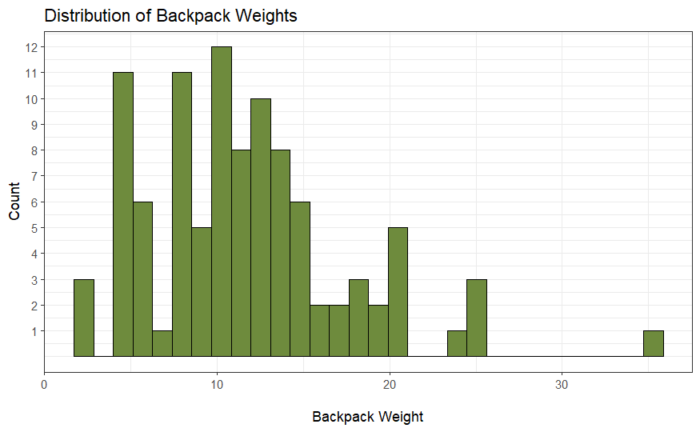

```r
backpack %>%
  ggplot() +
  aes(x = backpack_weight) +
  geom_histogram(colour = "black", fill = "darkolivegreen4") +
  theme_bw(base_size = 11) +
  scale_y_continuous(breaks = 1:13) +
  labs(title = "Distribution of Backpack Weights",
       x = "\nBackpack Weight",
       y = "Count")
```

The distribution of backpack weights is right skewed with one obvious outlier at 35.

# Question 3.

Are there differences in backpack weight between sex?

A good way to compare between means and ranges between sexes would be a boxplot.

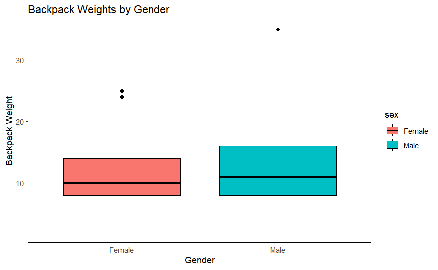

```r
backpack %>%
  ggplot() +
  aes(x = sex, y = backpack_weight, group = sex, colour = sex, fill = sex) +
  geom_boxplot(colour = "black") +
  theme_classic(base_size = 11) +
  labs(title = "Backpack Weights by Gender",
       x = "Gender",
       y = "Backpack Weight")
```

Overall the males show a greater tendency to carry heavier weights, but the overall medians and distributions are very similar.

# Question 4.

What is the relationship between body weight and backpack weight?

Scatterplots are often a good way to see if there are relationships between data;

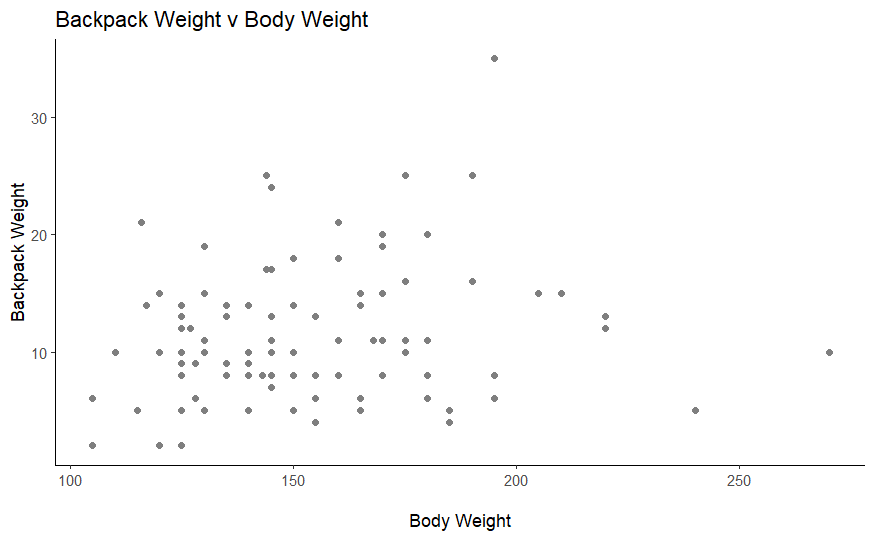

```r
backpack %>%
  ggplot() +
  aes(x = body_weight, y = backpack_weight) +
  geom_point(colour = "grey50") +
  theme_classic(base_size = 11) +
  labs(title = "Backpack Weight v Body Weight",
       x = "\nBody Weight",
       y = "Backpack Weight")
```

There’s no immediately obvious trend shown by this chart.

# Question 5.

Is this relationship different between men and women? Choose an appropriate plot and interpret your findings.

Use the same basic scatterplot configuration, but grouped by gender;

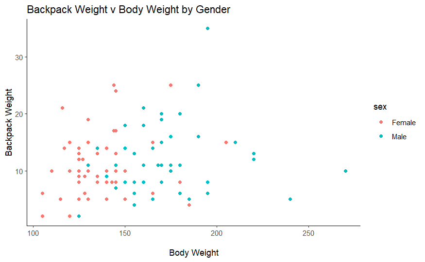

```r
backpack %>%
  ggplot() +
  aes(x = body_weight, y = backpack_weight, group = sex, colour = sex) +
  geom_point() +
  theme_classic(base_size = 11) +
  labs(title = "Backpack Weight v Body Weight by Gender",
       x = "\nBody Weight",
       y = "Backpack Weight"
       )
```

Even splitting the results by gender does not show any immediately obvious relationship between body weight and backpack weight.

# Question 6.

What proportion of students report back pain?

Normally a calculation would be easier to show this than a graph…

| n() |
| --- |
| 32 |

32 students report back pain…

| n() |
| --- |
| 100 |

…out of 100 = 32%.

Graphically;

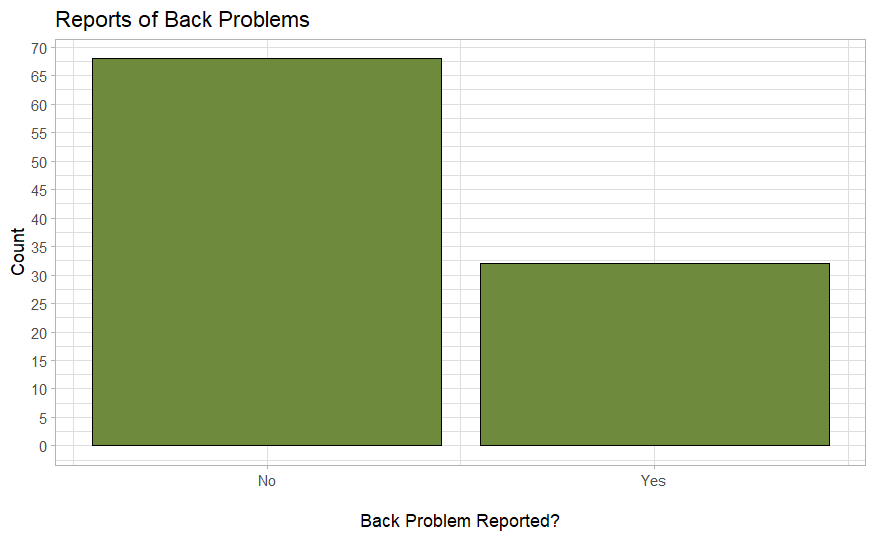

```r
backpack %>%
  ggplot() +
  aes(x = back_problems, group = back_problems) +
  geom_bar(colour = "black", position = "dodge", fill = "darkolivegreen4") +
  theme_light(base_size = 11) +
  scale_x_continuous(breaks = 0:1, labels = c("No", "Yes")) +
  scale_y_continuous(breaks = seq(0, 70, by = 5)) +
  labs(title = "Reports of Back Problems",
       x = "\nBack Problem Reported?",
       y = "Count"
       )
```

```r
NA
NA
```

The number of students reporting back problems was 32.

The number of students *not* reporting back problems was 68.

The overall proportion of students reporting pain was therefore 32%.

I tried various ways to represent this, but because there’s only one variable I struggled to show data labels on the graph. How do you refer to “count” when it’s being generated by ggplot without any external calculation? Is it necessary to `summarise(sum(back_problems))` beforehand and use that for labelling?

# Question 7.

Is this proportion different between men and women?

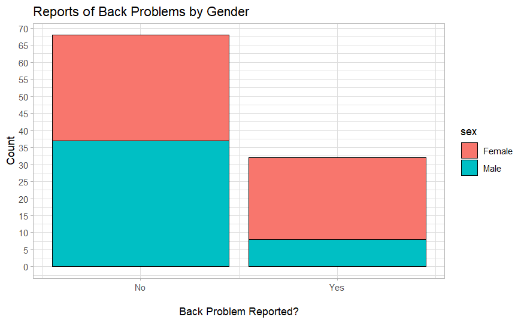

```r
backpack %>%
  ggplot() +
  aes(x = back_problems, group = sex, fill = sex, size = back_problems) +
  geom_bar(colour = "black") +
  theme_light(base_size = 11) +
  scale_x_continuous(breaks = 0:1, labels = c("No", "Yes")) +
  scale_y_continuous(breaks = seq(0, 70, by = 5)) +
  labs(title = "Reports of Back Problems by Gender",
       x = "\nBack Problem Reported?",
       y = "Count"
       )
```

The graph shows that a far higher proportion (~ 45%) of females reported back problems than compared to males (~ 18%).

I’m not convinced this was the best graph type to use for this! `geom_bar` and `geom_histogram` don’t take data labelling very easily from what I can see…

# Question 8.

Now you’ve investigated your data separately, create plots to describe the relationship between backpack weight, body weight, gender and reported backpain.

Try both backpack_weight and body_weight as well as the ratio.

Hint: faceting would be useful here.

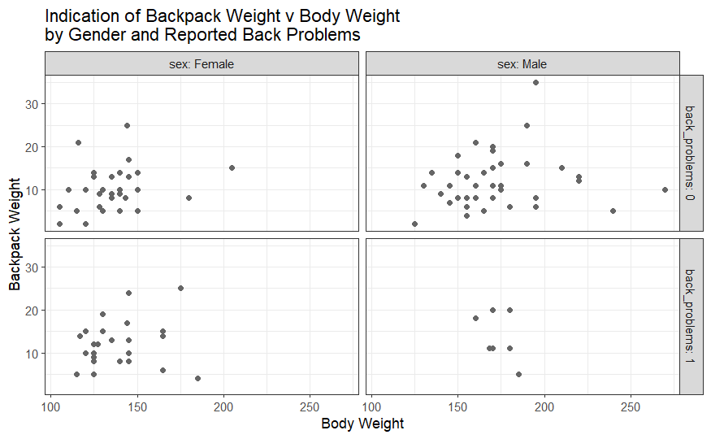

```r
backpack %>%
  ggplot() +
  aes(x = body_weight, y = backpack_weight) +
    geom_point(colour = "grey40") +
    facet_grid(back_problems ~ sex, labeller = "label_both") +
    theme_bw(base_size = 11) +
    labs(title = "Indication of Backpack Weight v Body Weight \nby Gender and Reported Back Problems",
         x = "Body Weight",
         y = "Backpack Weight"
         )
```

Males who reported *no* back pain had a wide spread of body weights and pack weights.

Males who *did* report problems were of fairly average body weight and pack weight relative to the whole male group.